# movies_dataset

## introduction

The dataset contains 5000+ movies with some metrics that measured can be classified how successful these movies are.

### What Questions Are We Trying To Answer?

- Q1. How have the success of genres changed over time - (Revenue/Rating)?
- Q1.1 How many movies of a particular genre have been released?
- Q1.2 Howhave the fortunes of the genres compared over time?
- Q2. How succesful are different genres (Revenue/Rating)?
- Q2.1 Which genres have the largest revenue and largest budgets?
- Q2.2 Which genres are most profitable after working out Return on Investment?
- Q2.3 Which genres are the most popular?
- Q3. Which Directors are the most successful (Revenue/Rating)?
- Q4. Which Attributes indicate a movie's chances of success (Revenue/Rating)?

### Describe Data's General Properties

```python
import pandas as pd
import numpy  as np
import matplotlib.pyplot as plt
import seaborn as sns
```

```python
# reads the data from the file - denotes as CSV, it has no header row, sets column headers
df = pd.read_csv('tmdb-movies.csv')
```

```python
df.head(2)
```

|  | id | imdb_id | popularity | budget | revenue | original_title | cast | homepage | director | tagline | ... | overview | runtime | genres | production_companies | release_date | vote_count | vote_average | release_year | budget_adj | revenue_adj |
| --- | --- | --- | --- | --- | --- | --- | --- | --- | --- | --- | --- | --- | --- | --- | --- | --- | --- | --- | --- | --- | --- |
| 0 | 135397 | tt0369610 | 32.985763 | 150000000 | 1513528810 | Jurassic World | Chris Pratt\|Bryce Dallas Howard\|Irrfan Khan\|Vi... | http://www.jurassicworld.com/ | Colin Trevorrow | The park is open. | ... | Twenty-two years after the events of Jurassic ... | 124 | Action\|Adventure\|Science Fiction\|Thriller | Universal Studios\|Amblin Entertainment\|Legenda... | 6/9/15 | 5562 | 6.5 | 2015 | 1.379999e+08 | 1.392446e+09 |
| 1 | 76341 | tt1392190 | 28.419936 | 150000000 | 378436354 | Mad Max: Fury Road | Tom Hardy\|Charlize Theron\|Hugh Keays-Byrne\|Nic... | http://www.madmaxmovie.com/ | George Miller | What a Lovely Day. | ... | An apocalyptic story set in the furthest reach... | 120 | Action\|Adventure\|Science Fiction\|Thriller | Village Roadshow Pictures\|Kennedy Miller Produ... | 5/13/15 | 6185 | 7.1 | 2015 | 1.379999e+08 | 3.481613e+08 |

2 rows × 21 columns

> Now lets take a look at some of the general properties of the data:

```python
df.info()
```

```
<class 'pandas.core.frame.DataFrame'>
RangeIndex: 10866 entries, 0 to 10865
Data columns (total 21 columns):
 #   Column                Non-Null Count  Dtype
---  ------                --------------  -----
 0   id                    10866 non-null  int64
 1   imdb_id               10856 non-null  object
 2   popularity            10866 non-null  float64
 3   budget                10866 non-null  int64
 4   revenue               10866 non-null  int64
 5   original_title        10866 non-null  object
 6   cast                  10790 non-null  object
 7   homepage              2936 non-null   object
 8   director              10822 non-null  object
 9   tagline               8042 non-null   object
 10  keywords              9373 non-null   object
 11  overview              10862 non-null  object
 12  runtime               10866 non-null  int64
 13  genres                10843 non-null  object
 14  production_companies  9836 non-null   object
 15  release_date          10866 non-null  object
 16  vote_count            10866 non-null  int64
 17  vote_average          10866 non-null  float64
 18  release_year          10866 non-null  int64
 19  budget_adj            10866 non-null  float64
 20  revenue_adj           10866 non-null  float64
dtypes: float64(4), int64(6), object(11)
memory usage: 1.7+ MB
```

```python
df.columns
```

```
Index(['id', 'imdb_id', 'popularity', 'budget', 'revenue', 'original_title',
       'cast', 'homepage', 'director', 'tagline', 'keywords', 'overview',
       'runtime', 'genres', 'production_companies', 'release_date',
       'vote_count', 'vote_average', 'release_year', 'budget_adj',
       'revenue_adj'],
      dtype='object')
```

```python
df.nunique()
```

```
id                      10865
imdb_id                 10855
popularity              10814
budget                    557
revenue                  4702
original_title          10571
cast                    10719
homepage                 2896
director                 5067
tagline                  7997
keywords                 8804
overview                10847
runtime                   247
genres                   2039
production_companies     7445
release_date             5909
vote_count               1289
vote_average               72
release_year               56
budget_adj               2614
revenue_adj              4840
dtype: int64
```

- we can see that ourdataset have 10866 entries and 21 columns
- Some attributes look like they will be useful for our research - we know the movie, release year, director ,cast, budget, revenue, rating which are all key to our research.
- Some of them contain a few missing values such as cast and director. While there are other attributes containing many more missing values such as homepage, tagline, keywords and production_companies.
- Columns imdb_id, homepage, tagline, overview look to be interesting but not of much value in the research required here, so may be worth dropping

> We can now start to take a look at some of the general statistics of the data:

```python
df.describe()
```

|  | id | popularity | budget | revenue | runtime | vote_count | vote_average | release_year | budget_adj | revenue_adj |
| --- | --- | --- | --- | --- | --- | --- | --- | --- | --- | --- |
| count | 10866.000000 | 10866.000000 | 1.086600e+04 | 1.086600e+04 | 10866.000000 | 10866.000000 | 10866.000000 | 10866.000000 | 1.086600e+04 | 1.086600e+04 |
| mean | 66064.177434 | 0.646441 | 1.462570e+07 | 3.982332e+07 | 102.070863 | 217.389748 | 5.974922 | 2001.322658 | 1.755104e+07 | 5.136436e+07 |
| std | 92130.136561 | 1.000185 | 3.091321e+07 | 1.170035e+08 | 31.381405 | 575.619058 | 0.935142 | 12.812941 | 3.430616e+07 | 1.446325e+08 |
| min | 5.000000 | 0.000065 | 0.000000e+00 | 0.000000e+00 | 0.000000 | 10.000000 | 1.500000 | 1960.000000 | 0.000000e+00 | 0.000000e+00 |
| 25% | 10596.250000 | 0.207583 | 0.000000e+00 | 0.000000e+00 | 90.000000 | 17.000000 | 5.400000 | 1995.000000 | 0.000000e+00 | 0.000000e+00 |
| 50% | 20669.000000 | 0.383856 | 0.000000e+00 | 0.000000e+00 | 99.000000 | 38.000000 | 6.000000 | 2006.000000 | 0.000000e+00 | 0.000000e+00 |
| 75% | 75610.000000 | 0.713817 | 1.500000e+07 | 2.400000e+07 | 111.000000 | 145.750000 | 6.600000 | 2011.000000 | 2.085325e+07 | 3.369710e+07 |
| max | 417859.000000 | 32.985763 | 4.250000e+08 | 2.781506e+09 | 900.000000 | 9767.000000 | 9.200000 | 2015.000000 | 4.250000e+08 | 2.827124e+09 |

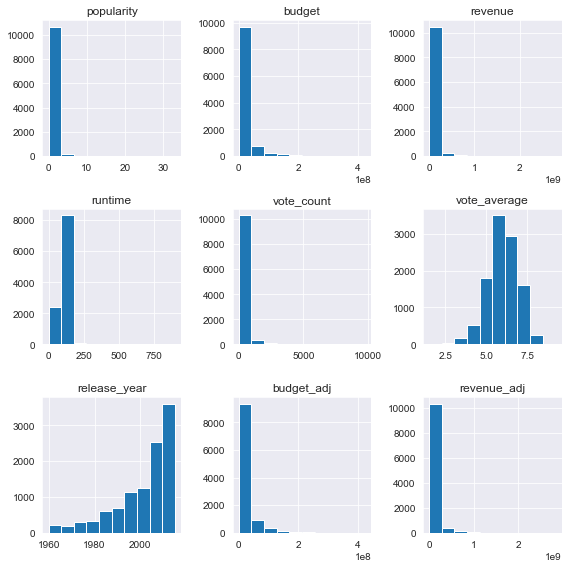

```python
df.drop(['id'] , axis = 1).hist(figsize=(8,8));
plt.tight_layout();
#df.drop(['id'], axis=1).hist(figsize=( 18,18));
```

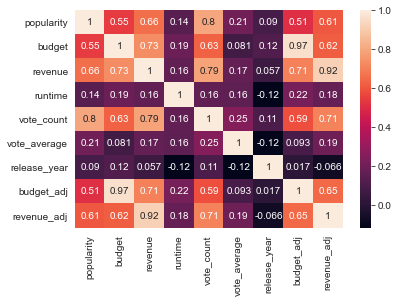

```python
sns.heatmap(df.drop(['id'] ,axis = 1).corr(),annot=True);
```

- Looks like the distributions are showing a lot of 0 values for revenue and budget and their respective adjusted

## Verify Data Quality

### Missing Data

```python
def values_table(data):
        val = data
        val_percent = 100 * val / len(data)
        val_table = pd.concat([val, val_percent], axis=1)
        val_table_ren_columns = val_table.rename(
        columns = {0 : 'Values', 1 : '% of Total Values'})
        val_table_ren_columns = val_table_ren_columns[
            val_table_ren_columns.iloc[:,0] != 0].sort_values(
        '% of Total Values', ascending=False).round(1)
        #print ("Your selected dataframe has " + str(data.shape[1]) + " columns.\n"
         #   "There are " + str(val_table_ren_columns.shape[0]) +
          #    " columns that have the values you filtered for.")
        return val_table_ren_columns
```

```python
values_table(df.isnull().sum())
```

|  | Values | % of Total Values |
| --- | --- | --- |
| homepage | 7930 | 37761.9 |
| tagline | 2824 | 13447.6 |
| keywords | 1493 | 7109.5 |
| production_companies | 1030 | 4904.8 |
| cast | 76 | 361.9 |
| director | 44 | 209.5 |
| genres | 23 | 109.5 |
| imdb_id | 10 | 47.6 |
| overview | 4 | 19.0 |

#### Options

- We may want to remove null rows entirely from the dataset
- We may want to drop the columns if they appear to be predominantly NA or not usful in our dataset
- We may want to fill the missing values with the mean values from the dataset

#### Decision

- We will drop columns imdb_id, homepage, tagline since we identified these as low importance for our research purposes anyway.
- We will keep keywords and production_companies as they may be interesting for research
- We need casts, director and genres for our analysis though - we can't infer these values from the data. We'll decide to drop rows with no values for these so that it doesn't affect analysis

### Outliers

> We noticed a lot of 0s in the histograms earlier, let's get some exact figures

```python
values_table((df == 0).sum())
```

|  | Values | % of Total Values |
| --- | --- | --- |
| revenue | 6016 | 28647.6 |
| revenue_adj | 6016 | 28647.6 |
| budget | 5696 | 27123.8 |
| budget_adj | 5696 | 27123.8 |
| runtime | 31 | 147.6 |

#### Options

- We may want to remove these rows entirely from the dataset
- We may want to drop the columns if they appear to be unreliable
- We may want to change the values with the mean values from the dataset, or another value of our choosing

#### Decision

- In this case, we do not want missing values for budget, budget_adj, revenu and revenue_adj affecting the research for our analysis, so we will make these values NULL instead

### Duplicates

```python
sum(df.duplicated())
```

```
1
```

Options We may want to remove duplicate rows entirely from the dataset.

## Data Cleansing

- Drop Un-Meaningful Columns

```python
df.drop(columns = ['imdb_id', 'homepage', 'tagline', 'overview'] , inplace = True)
```

#### Test

```python
df.shape[1] # we had 21 , now it is 17
```

```
17
```

- Drop Null Columns

```python
df.dropna(subset=['revenue','revenue_adj','budget','budget_adj','runtime'] , inplace = True)
```

```python
values_table((df == 0).sum())
```

|  | Values | % of Total Values |
| --- | --- | --- |
| revenue | 6016 | 35388.2 |
| revenue_adj | 6016 | 35388.2 |
| budget | 5696 | 33505.9 |
| budget_adj | 5696 | 33505.9 |
| runtime | 31 | 182.4 |

```python
#drop the null values in cast, director, genres columns
columns = ['cast', 'director', 'genres']
df.dropna(subset = columns, how='any', inplace=True)
```

#### Test

```python
values_table(df.isnull().sum())
```

|  | Values | % of Total Values |
| --- | --- | --- |
| keywords | 1425 | 8382.4 |
| production_companies | 959 | 5641.2 |

> we have a lot of 0 in our important columns

```python
df['revenue']     = df['revenue'].replace(0,np.nan)
df['revenue_adj'] = df['revenue_adj'].replace(0,np.nan)
df['budget']      = df['budget'].replace(0,np.nan)
df['budget_adj']  = df['budget_adj'].replace(0,np.nan)
df['runtime']     = df['runtime'].replace(0,np.nan)
```

#### Test

```python
values_table((df == 0).sum())
```

|  | Values | % of Total Values |
| --- | --- | --- |

- Drop duplicate records

```python
df.drop_duplicates(inplace = True)
```

#### Test

```python
sum(df.duplicated())
```

```
0
```

# Exploratory Data Analysis

- Q1. How have the success of genres changed over time (Revenue/Rating)?

```python
df.genres.unique()
```

```
array(['Action|Adventure|Science Fiction|Thriller',
       'Adventure|Science Fiction|Thriller',
       'Action|Adventure|Science Fiction|Fantasy', ...,
       'Action|Drama|Horror|Thriller', 'Adventure|Animation|Drama',
       'Action|Adventure|Drama|War|Romance'], dtype=object)
```

> we are going to split the genres first

> we will copy the original data

```python
df_movie = df.copy()
```

```python
df_movie['genres'] = df_movie['genres'].apply(lambda x : x.split("|")[0])
```

```python
df_movie['genres'].unique()
```

```
array(['Action', 'Adventure', 'Western', 'Science Fiction', 'Drama',
       'Family', 'Comedy', 'Crime', 'Romance', 'War', 'Thriller',
       'Fantasy', 'History', 'Mystery', 'Animation', 'Horror', 'Music',
       'Documentary', 'TV Movie'], dtype=object)
```

- How many movies of a particular genre have been released?

```python
df_movie.groupby(['release_year','genres']).count()['id'].unstack()
df_movie.groupby('genres').count().id #the number of movies in each genres
```

[output not shown]

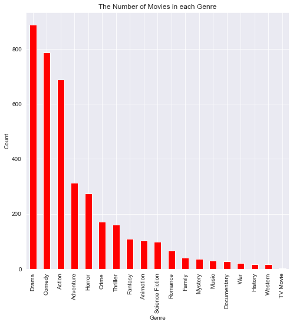

```python
sns.set_style('darkgrid')
sns.set_palette("Set1", 20, .65)
df_movie.groupby('genres').count()['id'].sort_values(ascending = False).plot(kind = 'bar', color = "red" , figsize=(8,8));
plt.xlabel('Genre')
plt.ylabel('Count')
plt.title('The Number of Movies in each Genre');
```

- Q2. How have the fortunes of the genres compared over time?

> we are interested in vote_average & budget and revenue in particular

```python
genre_year = df_movie.groupby(['genres','release_year']).mean()
```

```python
df_gyBudget = genre_year.pivot_table(index=['genres'], columns=['release_year'], values='budget', aggfunc=np.mean)
```

```python
df_gyGross = genre_year.pivot_table(index=['genres'], columns=['release_year'], values='revenue', aggfunc=np.mean)
```

```python
df_gyVote = genre_year.pivot_table(index=['genres'], columns=['release_year'], values='vote_average', aggfunc=np.mean)
```

[figure not shown]

```python
f, [axA, axB, axC] = plt.subplots(figsize=(100, 80), nrows=3)
cmap = sns.cubehelix_palette(start=1.3, rot=1.3, as_cmap=True)
sns.heatmap(df_gyBudget, xticklabels=5, cmap=cmap, linewidths=0.05, ax=axA)
sns.heatmap(df_gyGross, xticklabels=5, cmap=cmap, linewidths=0.05, ax=axB)
sns.heatmap(df_gyVote, xticklabels=5, cmap=cmap, linewidths=0.05, ax=axC)
axA.set_title('Average Budget over Time for each Genre')
axB.set_title('Average Revenue over Time for each Genre')
axC.set_title('Average Rating Score over Time for each Genre')
axA.set_xlabel('Release Years')
axA.set_ylabel('Genres')
axB.set_xlabel('Release Years')
axB.set_ylabel('Genres')
axC.set_xlabel('Release Years')
axC.set_ylabel('Genres')
plt.show()
```

- How succesful are different genres (Revenue/Rating)?

```python
df_movie.groupby('genres')[['budget','revenue','vote_average','popularity']].mean()
```

| genres | budget | revenue | vote_average | popularity |
| --- | --- | --- | --- | --- |
| Action | 5.174563e+07 | 1.359287e+08 | 5.996517 | 1.442326 |
| Adventure | 7.232108e+07 | 2.288291e+08 | 6.250955 | 1.905525 |
| Animation | 8.001165e+07 | 2.761320e+08 | 6.361165 | 1.712723 |
| Comedy | 2.621832e+07 | 7.879489e+07 | 6.017154 | 0.914765 |
| Crime | 2.595263e+07 | 7.138255e+07 | 6.460234 | 1.074895 |
| Documentary | 4.816005e+06 | 2.331455e+07 | 6.785714 | 0.312846 |
| Drama | 2.468618e+07 | 6.482288e+07 | 6.438695 | 0.928449 |
| Family | 6.037500e+07 | 2.175372e+08 | 6.100000 | 1.609295 |
| Fantasy | 5.541864e+07 | 1.595936e+08 | 6.080000 | 1.581660 |
| History | 3.533053e+07 | 1.136145e+08 | 6.494118 | 1.442235 |
| Horror | 1.525382e+07 | 5.507483e+07 | 5.749818 | 0.855787 |
| Music | 3.217241e+07 | 7.742144e+07 | 6.193103 | 0.914098 |
| Mystery | 3.048417e+07 | 7.211830e+07 | 6.136111 | 1.133780 |
| Romance | 2.794857e+07 | 1.017852e+08 | 6.451515 | 1.369972 |
| Science Fiction | 5.279701e+07 | 1.738652e+08 | 6.244898 | 1.931437 |
| TV Movie | 5.000000e+06 | 4.200000e+07 | 5.600000 | 0.273628 |
| Thriller | 3.357948e+07 | 7.880660e+07 | 5.993125 | 1.171430 |
| War | 5.721000e+07 | 1.334856e+08 | 6.480000 | 1.658497 |
| Western | 4.612500e+07 | 7.996166e+07 | 6.418750 | 1.193918 |

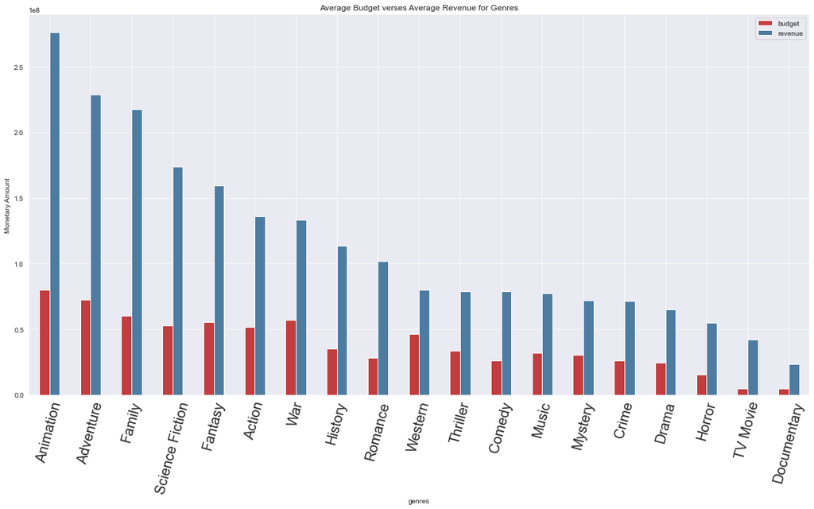

```python
f,ax=plt.subplots(figsize=(20, 10))
df_movie[['genres', 'budget', 'revenue']].groupby(['genres']).mean().sort_values(["revenue","budget"], ascending=False).plot(kind="bar",  ax=ax);
plt.xticks(rotation=75,fontsize=20)

ax.set(ylabel = 'Monetary Amount', title = 'Average Budget verses Average Revenue for Genres')

plt.show()
```

- Which genres are the most popular?

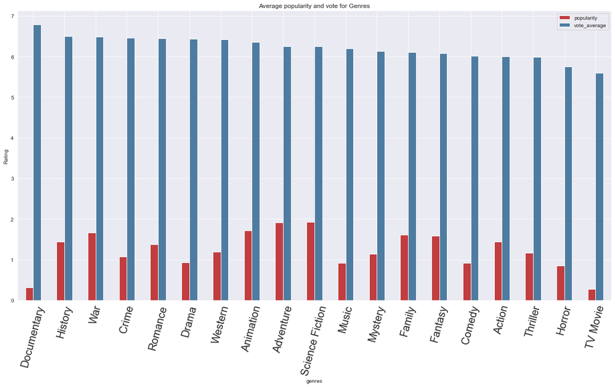

```python
f,ax=plt.subplots(figsize=(20, 10))
df_movie[['genres', 'popularity', 'vote_average']].groupby(['genres']).mean().sort_values(["vote_average"], ascending=False).plot(kind="bar",  ax=ax);
plt.xticks(rotation=75,fontsize=20)

ax.set(ylabel = 'Rating', title = 'Average popularity and vote for Genres')

plt.show()
```

- Which Directors are the most successful (Revenue/Rating)?

```python
df_director = df_movie.copy()
```

```python
df_director = df_director['director'].apply(lambda x:x.split("|")[0])
```

```python
#Create new dataframe
df_director_movies = df_movie
#split out the director field
df_director_movies['director'] = df_director_movies['director'].apply(lambda x: x.split("|")[0])
```

```python
#Create our new dataframe for the Sumation of revenue for directors over time
df_director_revenue = df_director_movies.groupby(['director', 'release_year']).sum()['revenue']#.nlargest(10)
df_director_revenue = pd.DataFrame(df_director_revenue)
```

```python
df_director_revenue
```

| director | release_year | revenue |
| --- | --- | --- |
| Frédéric Jardin | 2011 | 3358.0 |
| A.R. Murugadoss | 2008 | 76000000.0 |
| Aaron Blaise | 2003 | 250.0 |
| Aaron Norris | 1995 | 5093707.0 |
| Aaron Seltzer | 2006 | 48548426.0 |
| ... | ... | ... |
| Zack Snyder | 2013 | 662845518.0 |
| Zal Batmanglij | 2013 | 2401510.0 |
| Zana Briski | 2004 | 3515061.0 |
| Ãlex de la Iglesia | 2010 | 3218666.0 |
| Émile Gaudreault | 2003 | 3031801.0 |

3780 rows × 1 columns

```python
#Create new data frame for the total sumation of revenue for directors
df_director_revenue_total = df_director_revenue.groupby(['director']).sum()
df_director_revenue_total = pd.DataFrame(df_director_revenue_total)
df_director_revenue_total = df_director_revenue_total.sort_values(by = ['revenue'], ascending = False)
```

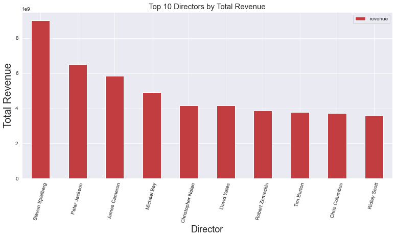

```python
#plot a barh graph
df_director_revenue_total[:10].plot(kind = 'bar', figsize=(13,6))

#setup the title and the labels
plt.title("Top 10 Directors by Total Revenue",fontsize=15)
plt.xticks(rotation=75)
plt.xlabel("Director",fontsize= 18)
plt.ylabel("Total Revenue",fontsize= 20)
sns.set_style("whitegrid")
```

- Which Attributes indicate a movie's chances of success (Revenue/Rating)?

```python
aux_df = df_movie[['revenue', 'budget', 'popularity', 'vote_average', 'release_year', 'runtime']]
```

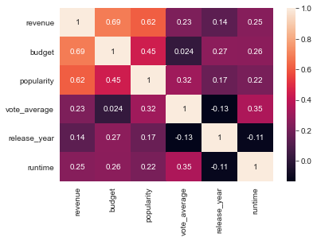

```python
sns.heatmap(aux_df.corr(),annot=True);
```

Looks like there is a positive correlation between budget and revenue, and a very slight positive correlation with release year and budget.